# LATIHAN MPDW MINGGU 4

Fajryanti Kusuma Wardani

2023-09-21

# PROSES MA(2)

Bangkitkan model MA(2) dengan $\theta_1 = 0.4$ dan $\theta_2 = 0.6$ sebanyak 300 data (manual dengan arima.sim)

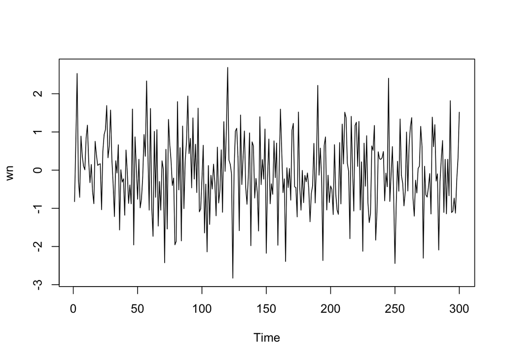

```r
wn <- rnorm(300)
ts.plot(wn)
```

```r
set.seed(98)
ma <- NULL
ma[1] <- wn[1]
ma[2] <- wn[2]
```

```r
for(i in 3:300){
   ma[i] <- wn[i] + 0.4 * wn[i - 1] + 0.6 * wn[i - 2]
}
ma
```

```
##   [1] -0.824266093  0.731003546  2.328541864  1.198795552  0.705537155
##   [6]  0.454045704  0.299173164  0.787996431  0.273926260  0.910353554
##  [11]  1.520361340  1.194592962  0.466434039  0.147511567 -0.696411176
##  [16] -1.013132447  0.066926017  0.170407650  0.735687381  0.438960449
##  [21]  0.302318729 -0.878079720  0.183644479  0.509511858  1.732398147
##  [26]  2.674144719  1.637072017  1.774878554  2.019458713  1.291658183
##  [31]  0.684783985 -1.194151350 -0.465314681 -0.708033056  0.779811935
##  [36] -1.346806149 -0.218534466 -1.249391293 -0.346353973 -1.457846721
##  [41] -0.080704759 -0.563321605 -0.581280408 -0.777719275 -1.558698032
##  [46]  1.013615169 -1.846233085  1.046989368 -0.752480747 -0.209738296
##  [51]  0.024036326 -1.329955971 -0.984650101 -1.055948705  0.412063931
##  [56]  0.640296373  3.039826026  1.594136384  0.531223772  1.460673741
##  [61] -0.973246985 -1.160898465 -0.272262011 -1.343572417  1.384136506
##  [66] -1.466411422 -0.248518561 -2.044470897 -0.353150758 -0.506480882
##  [71] -2.268340619 -0.410843140 -2.777715068  1.038532165  0.279180063
```

[output cut: 45 more lines]

```r
ma1 <- arima.sim(list(order=c(0,0,2), ma= c(0.4, 0.6)), n=300)
ma1
```

```
## Time Series:
## Start = 1
## End = 300
## Frequency = 1
##   [1] -0.905547026 -2.433470567 -0.586298352  0.170707787  0.064371059
##   [6]  0.033122966 -1.130640043  0.158254837  0.442981248  0.968263786
##  [11] -0.022170666  0.140991373  0.950861362  0.757845409 -1.103041723
##  [16] -0.023210803  0.005030246 -0.069540754  0.743815942 -0.046538513
##  [21] -1.108463024 -2.397422073 -2.996438153 -1.477014523 -0.915409375
##  [26]  0.087027260 -0.262328904 -1.953089772 -2.046282640 -2.691171901
##  [31] -0.044676734 -1.332061558  0.116322653 -3.201667731 -0.580171416
##  [36] -0.529140154  0.154305921 -0.184165647 -0.180392148 -2.816265845
##  [41] -2.126572296 -0.815186961  0.487125238  0.346463636 -0.316206142
##  [46]  0.045029881  1.005006346  0.247310111 -0.105541527 -1.020679522
##  [51]  0.326091815  0.878121529  1.922325119  2.150800263 -0.840083035
```

[output cut: 49 more lines]

Buat plot time series, plot ACF, plot PACF, dan plot EACF. Identifikasi apakah data tersebut stasioner ### Plot Time Series

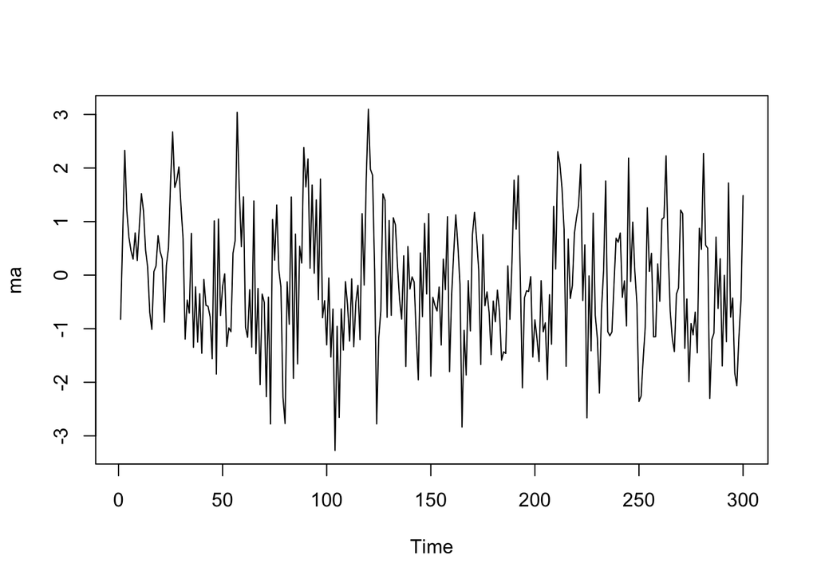

```r
ts.plot(ma)
```

### Plot ACF

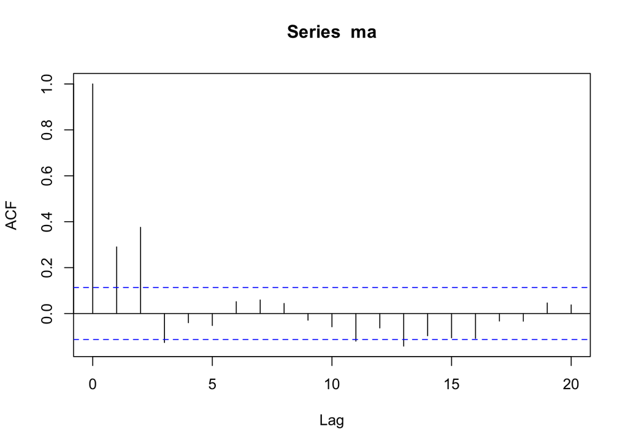

```r
acf(ma,lag.max = 20)
```

### Plot PACF

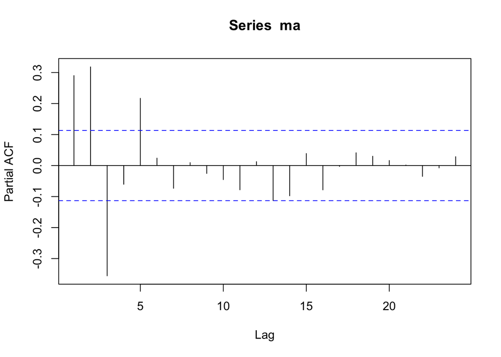

```r
pacf(ma)
```

Berdasarkan plot PACF tersebut, terlihat bahwa plot PACF cenderung *tails off* dan membentuk gelombang sinus

### Plot EACF

```r
TSA::eacf(ma)
```

```
## AR/MA
##   0 1 2 3 4 5 6 7 8 9 10 11 12 13
## 0 x x x o o o o o o o x  o  x  o
## 1 x x x o o o o o o o o  o  o  o
## 2 x x x x o o o o o o o  o  o  o
## 3 x x x x o o o o o o o  o  o  o
## 4 x x x o x o o o o o o  o  o  o
## 5 x x x x o o o o o o o  o  o  o
## 6 x x o x o o o o o o o  o  o  o
## 7 o x x o x o o o o o o  o  o  o
```

Buat scatterplot antara $Y_t$ dengan $Y_{t-1}$, $Y_t$ dengan $Y_{t-2}$ serta $Y_t$ dengan $Y_{t-3}$

#### Korelasi antara $Y_t$ dengan $Y_{t-1}$

```r
#Yt
yt_ma <- ma[-1]
yt_ma
```

```
##   [1]  0.731003546  2.328541864  1.198795552  0.705537155  0.454045704
##   [6]  0.299173164  0.787996431  0.273926260  0.910353554  1.520361340
##  [11]  1.194592962  0.466434039  0.147511567 -0.696411176 -1.013132447
##  [16]  0.066926017  0.170407650  0.735687381  0.438960449  0.302318729
##  [21] -0.878079720  0.183644479  0.509511858  1.732398147  2.674144719
##  [26]  1.637072017  1.774878554  2.019458713  1.291658183  0.684783985
##  [31] -1.194151350 -0.465314681 -0.708033056  0.779811935 -1.346806149
##  [36] -0.218534466 -1.249391293 -0.346353973 -1.457846721 -0.080704759
##  [41] -0.563321605 -0.581280408 -0.777719275 -1.558698032  1.013615169
##  [46] -1.846233085  1.046989368 -0.752480747 -0.209738296  0.024036326
##  [51] -1.329955971 -0.984650101 -1.055948705  0.412063931  0.640296373
##  [56]  3.039826026  1.594136384  0.531223772  1.460673741 -0.973246985
##  [61] -1.160898465 -0.272262011 -1.343572417  1.384136506 -1.466411422
##  [66] -0.248518561 -2.044470897 -0.353150758 -0.506480882 -2.268340619
##  [71] -0.410843140 -2.777715068  1.038532165  0.279180063  1.309349085
```

[output cut: 45 more lines]

```r
#Yt-1
yt_1_ma <- ma[-300]
yt_1_ma
```

```
##   [1] -0.824266093  0.731003546  2.328541864  1.198795552  0.705537155
##   [6]  0.454045704  0.299173164  0.787996431  0.273926260  0.910353554
##  [11]  1.520361340  1.194592962  0.466434039  0.147511567 -0.696411176
##  [16] -1.013132447  0.066926017  0.170407650  0.735687381  0.438960449
##  [21]  0.302318729 -0.878079720  0.183644479  0.509511858  1.732398147
##  [26]  2.674144719  1.637072017  1.774878554  2.019458713  1.291658183
##  [31]  0.684783985 -1.194151350 -0.465314681 -0.708033056  0.779811935
##  [36] -1.346806149 -0.218534466 -1.249391293 -0.346353973 -1.457846721
##  [41] -0.080704759 -0.563321605 -0.581280408 -0.777719275 -1.558698032
##  [46]  1.013615169 -1.846233085  1.046989368 -0.752480747 -0.209738296
##  [51]  0.024036326 -1.329955971 -0.984650101 -1.055948705  0.412063931
##  [56]  0.640296373  3.039826026  1.594136384  0.531223772  1.460673741
##  [61] -0.973246985 -1.160898465 -0.272262011 -1.343572417  1.384136506
##  [66] -1.466411422 -0.248518561 -2.044470897 -0.353150758 -0.506480882
##  [71] -2.268340619 -0.410843140 -2.777715068  1.038532165  0.279180063
```

[output cut: 45 more lines]

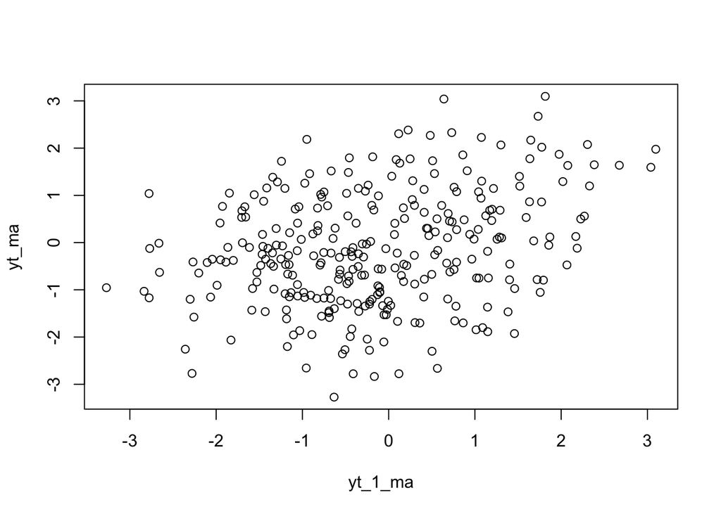

```r
plot(y=yt_ma,x=yt_1_ma)
```

Berdasarkan scatterplot tersebut, terlihat bahwa terdapat hubungan positif antara $Y_t$ dengan $Y_{t-1}$. Hal ini sesuai dengan teori yang ada

```r
cor(yt_ma,yt_1_ma)
```

```
## [1] 0.2912249
```

#### Korelasi antara $Y_t$ dengan $Y_{t-2}$

```r
#Yt
yt_ma2 <- ma[-c(1,2)]
yt_ma2
```

```
##   [1]  2.328541864  1.198795552  0.705537155  0.454045704  0.299173164
##   [6]  0.787996431  0.273926260  0.910353554  1.520361340  1.194592962
##  [11]  0.466434039  0.147511567 -0.696411176 -1.013132447  0.066926017
##  [16]  0.170407650  0.735687381  0.438960449  0.302318729 -0.878079720
##  [21]  0.183644479  0.509511858  1.732398147  2.674144719  1.637072017
##  [26]  1.774878554  2.019458713  1.291658183  0.684783985 -1.194151350
##  [31] -0.465314681 -0.708033056  0.779811935 -1.346806149 -0.218534466
##  [36] -1.249391293 -0.346353973 -1.457846721 -0.080704759 -0.563321605
##  [41] -0.581280408 -0.777719275 -1.558698032  1.013615169 -1.846233085
##  [46]  1.046989368 -0.752480747 -0.209738296  0.024036326 -1.329955971
##  [51] -0.984650101 -1.055948705  0.412063931  0.640296373  3.039826026
##  [56]  1.594136384  0.531223772  1.460673741 -0.973246985 -1.160898465
##  [61] -0.272262011 -1.343572417  1.384136506 -1.466411422 -0.248518561
##  [66] -2.044470897 -0.353150758 -0.506480882 -2.268340619 -0.410843140
##  [71] -2.777715068  1.038532165  0.279180063  1.309349085  0.099055853
```

[output cut: 45 more lines]

```r
#Yt-2
yt_2_ma <- ma[-c(299,300)]
yt_2_ma
```

```
##   [1] -0.824266093  0.731003546  2.328541864  1.198795552  0.705537155
##   [6]  0.454045704  0.299173164  0.787996431  0.273926260  0.910353554
##  [11]  1.520361340  1.194592962  0.466434039  0.147511567 -0.696411176
##  [16] -1.013132447  0.066926017  0.170407650  0.735687381  0.438960449
##  [21]  0.302318729 -0.878079720  0.183644479  0.509511858  1.732398147
##  [26]  2.674144719  1.637072017  1.774878554  2.019458713  1.291658183
##  [31]  0.684783985 -1.194151350 -0.465314681 -0.708033056  0.779811935
##  [36] -1.346806149 -0.218534466 -1.249391293 -0.346353973 -1.457846721
##  [41] -0.080704759 -0.563321605 -0.581280408 -0.777719275 -1.558698032
##  [46]  1.013615169 -1.846233085  1.046989368 -0.752480747 -0.209738296
##  [51]  0.024036326 -1.329955971 -0.984650101 -1.055948705  0.412063931
##  [56]  0.640296373  3.039826026  1.594136384  0.531223772  1.460673741
##  [61] -0.973246985 -1.160898465 -0.272262011 -1.343572417  1.384136506
##  [66] -1.466411422 -0.248518561 -2.044470897 -0.353150758 -0.506480882
##  [71] -2.268340619 -0.410843140 -2.777715068  1.038532165  0.279180063
```

[output cut: 45 more lines]

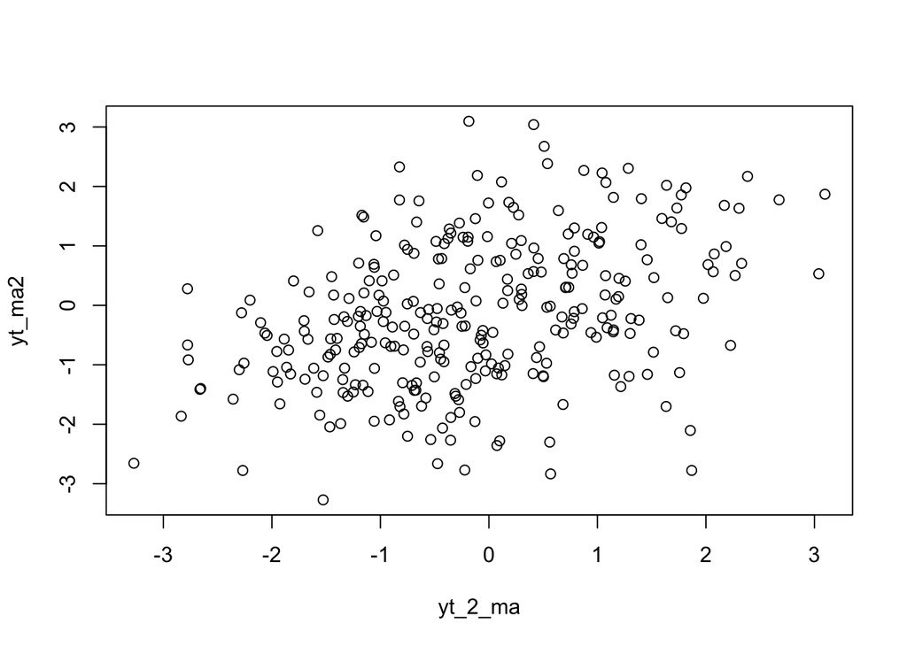

```r
plot(y=yt_ma2,x=yt_2_ma)
```

```r
cor(yt_ma2,yt_2_ma)
```

```
## [1] 0.3772983
```

##### Korelasi antara $Y_t$ dengan $Y_{t-3}$

```r
#Yt
yt_ma3 <- ma[-c(1,2,3)]
yt_ma3
```

```
##   [1]  1.198795552  0.705537155  0.454045704  0.299173164  0.787996431
##   [6]  0.273926260  0.910353554  1.520361340  1.194592962  0.466434039
##  [11]  0.147511567 -0.696411176 -1.013132447  0.066926017  0.170407650
##  [16]  0.735687381  0.438960449  0.302318729 -0.878079720  0.183644479
##  [21]  0.509511858  1.732398147  2.674144719  1.637072017  1.774878554
##  [26]  2.019458713  1.291658183  0.684783985 -1.194151350 -0.465314681
##  [31] -0.708033056  0.779811935 -1.346806149 -0.218534466 -1.249391293
##  [36] -0.346353973 -1.457846721 -0.080704759 -0.563321605 -0.581280408
##  [41] -0.777719275 -1.558698032  1.013615169 -1.846233085  1.046989368
##  [46] -0.752480747 -0.209738296  0.024036326 -1.329955971 -0.984650101
##  [51] -1.055948705  0.412063931  0.640296373  3.039826026  1.594136384
##  [56]  0.531223772  1.460673741 -0.973246985 -1.160898465 -0.272262011
##  [61] -1.343572417  1.384136506 -1.466411422 -0.248518561 -2.044470897
##  [66] -0.353150758 -0.506480882 -2.268340619 -0.410843140 -2.777715068
##  [71]  1.038532165  0.279180063  1.309349085  0.099055853 -0.222589890
```

[output cut: 45 more lines]

```r
#Yt-2
yt_3_ma <- ma[-c(298,299,300)]
yt_3_ma
```

```
##   [1] -0.824266093  0.731003546  2.328541864  1.198795552  0.705537155
##   [6]  0.454045704  0.299173164  0.787996431  0.273926260  0.910353554
##  [11]  1.520361340  1.194592962  0.466434039  0.147511567 -0.696411176
##  [16] -1.013132447  0.066926017  0.170407650  0.735687381  0.438960449
##  [21]  0.302318729 -0.878079720  0.183644479  0.509511858  1.732398147
##  [26]  2.674144719  1.637072017  1.774878554  2.019458713  1.291658183
##  [31]  0.684783985 -1.194151350 -0.465314681 -0.708033056  0.779811935
##  [36] -1.346806149 -0.218534466 -1.249391293 -0.346353973 -1.457846721
##  [41] -0.080704759 -0.563321605 -0.581280408 -0.777719275 -1.558698032
##  [46]  1.013615169 -1.846233085  1.046989368 -0.752480747 -0.209738296
##  [51]  0.024036326 -1.329955971 -0.984650101 -1.055948705  0.412063931
##  [56]  0.640296373  3.039826026  1.594136384  0.531223772  1.460673741
##  [61] -0.973246985 -1.160898465 -0.272262011 -1.343572417  1.384136506
##  [66] -1.466411422 -0.248518561 -2.044470897 -0.353150758 -0.506480882
##  [71] -2.268340619 -0.410843140 -2.777715068  1.038532165  0.279180063
```

[output cut: 45 more lines]

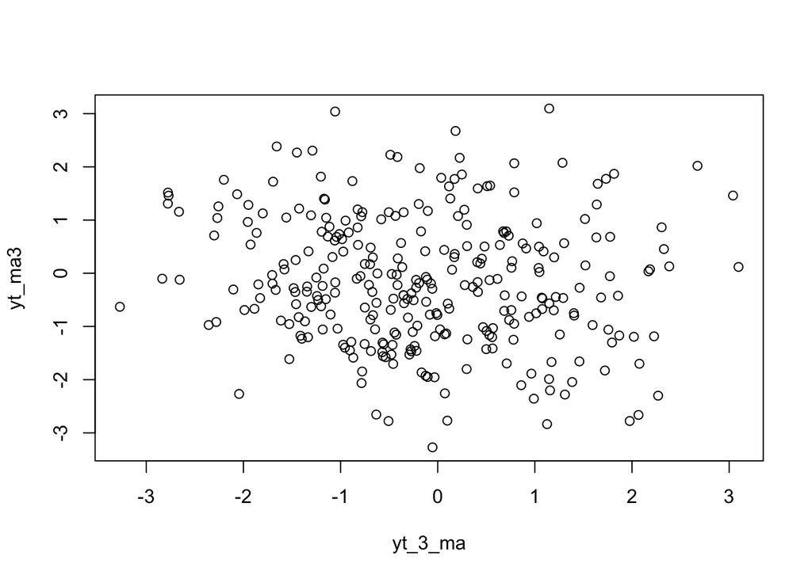

```r
plot(y=yt_ma3,x=yt_3_ma)
```

```r
cor(yt_ma3,yt_3_ma)
```

```
## [1] -0.1276999
```

# PROSES AR(2)

```r
n<-length(wn)
n
```

```
## [1] 300
```

```r
ar <- c(1:n)
for (i in 3:n) {ar[i]<-wn[i]+0.5*ar[i-1]+0.2*ar[i-2]}
ar
```

```
##   [1]  1.00000000  2.00000000  3.73070010  2.01326343  1.04072348  1.81313140
##   [7]  1.48506573  1.21094326  0.91188419  1.54125407  2.13047623  1.59121896
##  [13]  0.89456334  0.91325557  0.07632206 -0.65727101  0.44031922  0.48448683
##  [19]  0.45546788  0.47605865  0.49577432 -0.69249780  0.25079827  0.91861252
##  [25]  1.57044350  2.65967017  1.96811889  2.14675844  3.03963866  2.23331596
##  [31]  1.35213032 -0.09292780  0.46838318  0.13919826  0.82699820 -1.12511171
##  [37] -0.38734396 -0.73214024 -0.67040187 -1.66066297 -0.43738525 -0.61753708
##  [43] -1.26705722 -1.14640353 -1.70707726  0.51660196 -2.04083765 -0.04667257
##  [49] -0.35752100 -0.94968195 -0.26206376 -1.30768465 -1.46678748 -1.15463659
##  [55]  0.06158995  0.16308129  2.42903976  1.68927189  0.28370469  2.09379470
##  [61]  0.11279964 -1.25785703  0.40907891 -0.75697389  0.76217362 -1.23429214
##  [67] -0.76294311 -1.67511767 -0.74564408 -0.68405519 -2.91571521 -1.04996249
##  [73] -2.64898654 -0.20643239  0.03946256  0.22197143 -0.28296221 -0.30505651
##  [79] -2.16447733 -3.00649589 -0.14238097 -1.18830952 -0.03422377 -2.10703882
##  [85]  0.09413759 -1.38224350 -0.42200867  0.24310044  1.97815886  1.47042587
```

[output cut: 35 more lines]

```r
ar1 <- arima.sim(list(order=c(2,0,0), ar=c(0.5, 0.2)), n=300)
ar1
```

```
## Time Series:
## Start = 1
## End = 300
## Frequency = 1
##   [1] -0.124736784 -1.896791539 -0.562807601  1.159104428  3.299534394
##   [6]  2.067161982  1.842932713  1.264435734  1.956030504  0.992486121
##  [11]  1.039133643  2.034997449  0.895519840  0.014866315  0.020096926
##  [16]  0.883564418 -0.831009708  0.243451887 -0.245021025 -0.010865471
##  [21]  1.621304334 -0.321110251  1.970725051 -0.272392699  0.950295234
##  [26]  0.223149582  0.338112988  0.209813576  1.073021450  1.638316241
##  [31]  2.437857000  1.356087394  1.085048281 -1.028938179 -0.686108406
##  [36] -1.583040586 -0.315806330 -0.004282647 -0.560399998 -1.453235465
##  [41] -2.224727534 -0.463492111 -1.276102170 -0.951898668 -0.323161048
##  [46] -0.345793333  0.781004080  0.326029086  2.158404358  1.696809778
##  [51]  1.175809702  0.990714596  0.707959455  0.414554454  0.527996679
```

[output cut: 49 more lines]

Buat plot time series, plot ACF, plot PACF, dan plot EACF. Identifikasi apakah data tersebut stasioner ### Plot Time Series

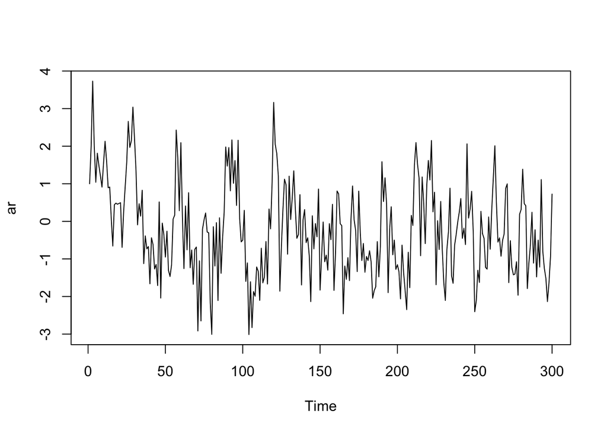

```r
ts.plot(ar)
```

Berdasarkan plot time series tersebut terlihat bahwa data cenderung stasioner pada rataan

### Plot ACF

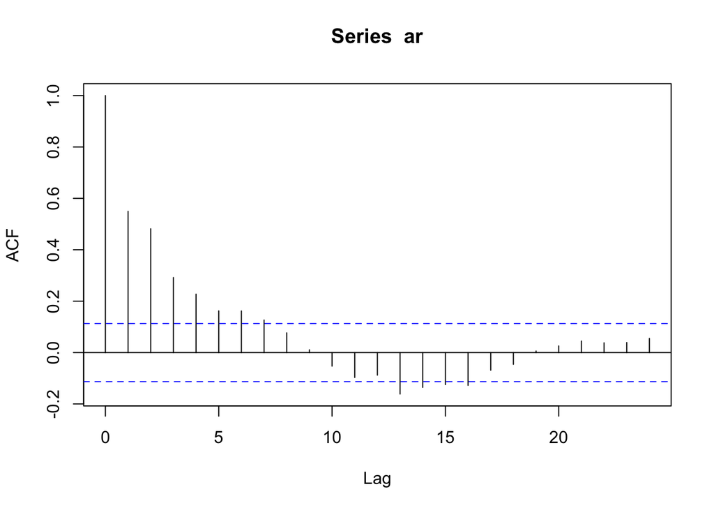

```r
acf(ar)
```

Berdasarkan plot ACF tersebut terlihat bahwa plot ACF cenderung *tails off* dan cenderung membentuk pola grafik sinus

### Plot PACF

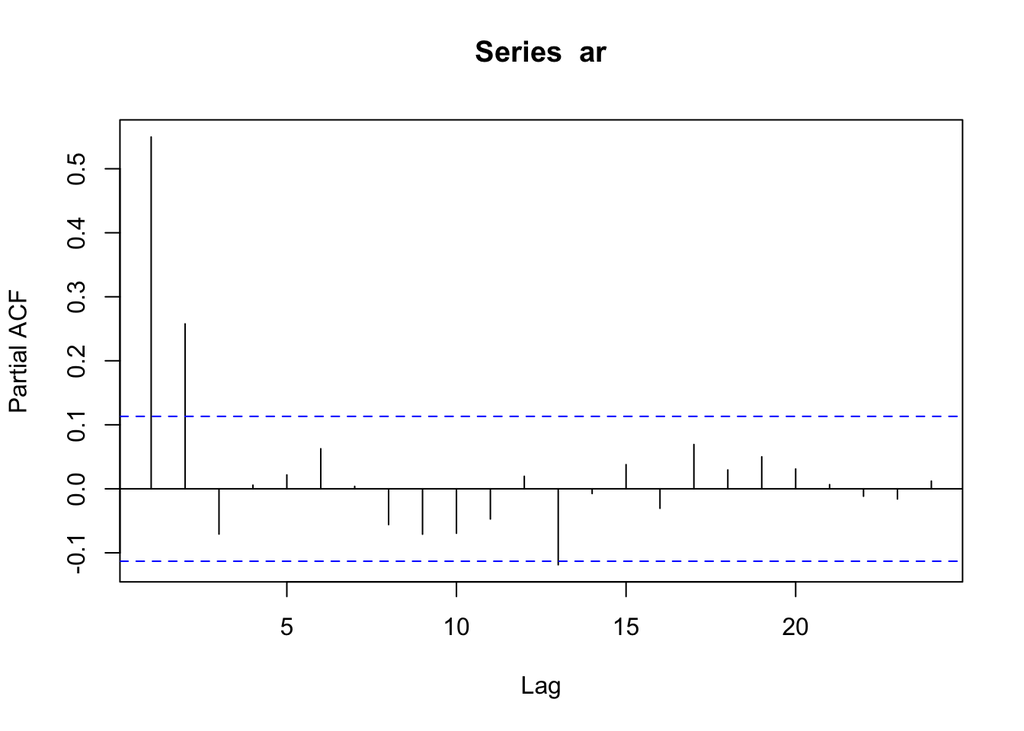

```r
pacf(ar)
```

### Plot EACF

```r
TSA::eacf(ar)
```

```
## AR/MA
##   0 1 2 3 4 5 6 7 8 9 10 11 12 13
## 0 x x x x x x x o o o o  o  x  x
## 1 x x o o o o o o o o o  o  o  o
## 2 x o o o o o o o o o o  o  o  o
## 3 o o o x o o o o o o o  o  o  o
## 4 x o o o o o o o o o o  o  o  o
## 5 x o x o o o o o o o o  o  o  o
## 6 x x x o o o o o o o o  o  o  o
## 7 x x o o o o o o o o o  o  o  o
```

### Scatterplot Antar Lag

#### Korelasi antara $Y_t$ dengan $Y_{t-1}$

```r
#Yt
yt_ar <- ar[-1]
yt_ar
```

```
##   [1]  2.00000000  3.73070010  2.01326343  1.04072348  1.81313140  1.48506573
##   [7]  1.21094326  0.91188419  1.54125407  2.13047623  1.59121896  0.89456334
##  [13]  0.91325557  0.07632206 -0.65727101  0.44031922  0.48448683  0.45546788
##  [19]  0.47605865  0.49577432 -0.69249780  0.25079827  0.91861252  1.57044350
##  [25]  2.65967017  1.96811889  2.14675844  3.03963866  2.23331596  1.35213032
##  [31] -0.09292780  0.46838318  0.13919826  0.82699820 -1.12511171 -0.38734396
##  [37] -0.73214024 -0.67040187 -1.66066297 -0.43738525 -0.61753708 -1.26705722
##  [43] -1.14640353 -1.70707726  0.51660196 -2.04083765 -0.04667257 -0.35752100
##  [49] -0.94968195 -0.26206376 -1.30768465 -1.46678748 -1.15463659  0.06158995
##  [55]  0.16308129  2.42903976  1.68927189  0.28370469  2.09379470  0.11279964
##  [61] -1.25785703  0.40907891 -0.75697389  0.76217362 -1.23429214 -0.76294311
##  [67] -1.67511767 -0.74564408 -0.68405519 -2.91571521 -1.04996249 -2.64898654
##  [73] -0.20643239  0.03946256  0.22197143 -0.28296221 -0.30505651 -2.16447733
##  [79] -3.00649589 -0.14238097 -1.18830952 -0.03422377 -2.10703882  0.09413759
##  [85] -1.38224350 -0.42200867  0.24310044  1.97815886  1.47042587  1.96269398
```

[output cut: 35 more lines]

```r
#Yt-1
yt_1_ar <- ar[-300]
yt_1_ar
```

```
##   [1]  1.00000000  2.00000000  3.73070010  2.01326343  1.04072348  1.81313140
##   [7]  1.48506573  1.21094326  0.91188419  1.54125407  2.13047623  1.59121896
##  [13]  0.89456334  0.91325557  0.07632206 -0.65727101  0.44031922  0.48448683
##  [19]  0.45546788  0.47605865  0.49577432 -0.69249780  0.25079827  0.91861252
##  [25]  1.57044350  2.65967017  1.96811889  2.14675844  3.03963866  2.23331596
##  [31]  1.35213032 -0.09292780  0.46838318  0.13919826  0.82699820 -1.12511171
##  [37] -0.38734396 -0.73214024 -0.67040187 -1.66066297 -0.43738525 -0.61753708
##  [43] -1.26705722 -1.14640353 -1.70707726  0.51660196 -2.04083765 -0.04667257
##  [49] -0.35752100 -0.94968195 -0.26206376 -1.30768465 -1.46678748 -1.15463659
##  [55]  0.06158995  0.16308129  2.42903976  1.68927189  0.28370469  2.09379470
##  [61]  0.11279964 -1.25785703  0.40907891 -0.75697389  0.76217362 -1.23429214
##  [67] -0.76294311 -1.67511767 -0.74564408 -0.68405519 -2.91571521 -1.04996249
##  [73] -2.64898654 -0.20643239  0.03946256  0.22197143 -0.28296221 -0.30505651
##  [79] -2.16447733 -3.00649589 -0.14238097 -1.18830952 -0.03422377 -2.10703882
##  [85]  0.09413759 -1.38224350 -0.42200867  0.24310044  1.97815886  1.47042587
```

[output cut: 35 more lines]

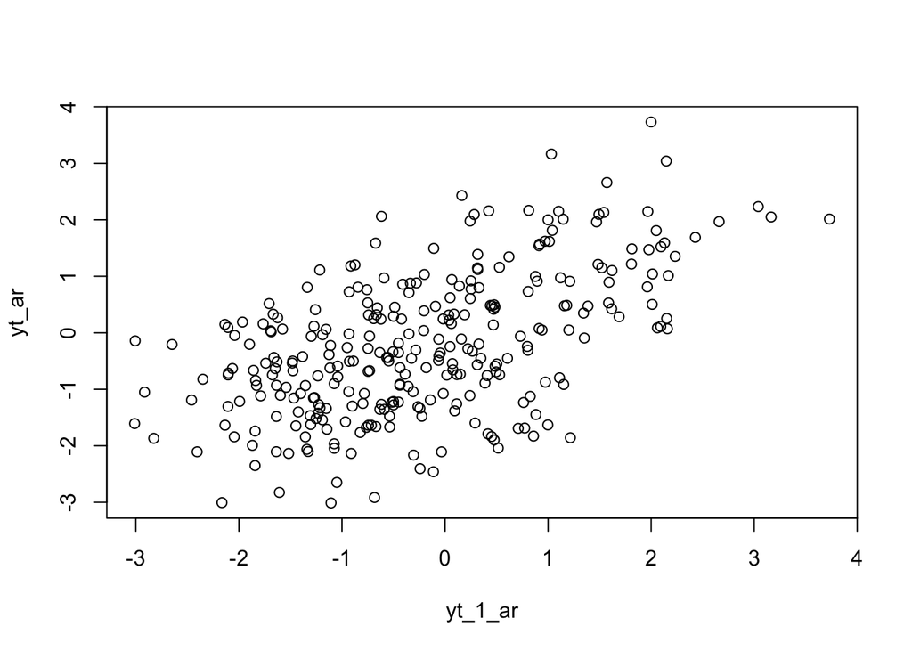

```r
plot(y=yt_ar,x=yt_1_ar)
```

Berdasarkan scatterplot tersebut, terlihat bahwa terdapat hubungan positif antara $Y_t$ dengan $Y_{t-1}$. Hal ini sesuai dengan teori yang ada

```r
cor(yt_ar,yt_1_ar)
```

```
## [1] 0.5510127
```

Korelasi antara $Y_t$ dengan $Y_{t-1}$ dari hasil simulasi mendekati perhitungan teoritis yaitu $\rho_1=\phi^1=0.6$

#### Korelasi antara $Y_t$ dengan $Y_{t-2}$

```r
#Yt
yt_ar2 <- ar[-c(1,2)]
yt_ar2
```

```
##   [1]  3.73070010  2.01326343  1.04072348  1.81313140  1.48506573  1.21094326
##   [7]  0.91188419  1.54125407  2.13047623  1.59121896  0.89456334  0.91325557
##  [13]  0.07632206 -0.65727101  0.44031922  0.48448683  0.45546788  0.47605865
##  [19]  0.49577432 -0.69249780  0.25079827  0.91861252  1.57044350  2.65967017
##  [25]  1.96811889  2.14675844  3.03963866  2.23331596  1.35213032 -0.09292780
##  [31]  0.46838318  0.13919826  0.82699820 -1.12511171 -0.38734396 -0.73214024
##  [37] -0.67040187 -1.66066297 -0.43738525 -0.61753708 -1.26705722 -1.14640353
##  [43] -1.70707726  0.51660196 -2.04083765 -0.04667257 -0.35752100 -0.94968195
##  [49] -0.26206376 -1.30768465 -1.46678748 -1.15463659  0.06158995  0.16308129
##  [55]  2.42903976  1.68927189  0.28370469  2.09379470  0.11279964 -1.25785703
##  [61]  0.40907891 -0.75697389  0.76217362 -1.23429214 -0.76294311 -1.67511767
##  [67] -0.74564408 -0.68405519 -2.91571521 -1.04996249 -2.64898654 -0.20643239
##  [73]  0.03946256  0.22197143 -0.28296221 -0.30505651 -2.16447733 -3.00649589
##  [79] -0.14238097 -1.18830952 -0.03422377 -2.10703882  0.09413759 -1.38224350
##  [85] -0.42200867  0.24310044  1.97815886  1.47042587  1.96269398  0.81235965
```

[output cut: 35 more lines]

```r
#Yt-2
yt_2_ar <- ar[-c(299,300)]
yt_2_ar
```

```
##   [1]  1.00000000  2.00000000  3.73070010  2.01326343  1.04072348  1.81313140
##   [7]  1.48506573  1.21094326  0.91188419  1.54125407  2.13047623  1.59121896
##  [13]  0.89456334  0.91325557  0.07632206 -0.65727101  0.44031922  0.48448683
##  [19]  0.45546788  0.47605865  0.49577432 -0.69249780  0.25079827  0.91861252
##  [25]  1.57044350  2.65967017  1.96811889  2.14675844  3.03963866  2.23331596
##  [31]  1.35213032 -0.09292780  0.46838318  0.13919826  0.82699820 -1.12511171
##  [37] -0.38734396 -0.73214024 -0.67040187 -1.66066297 -0.43738525 -0.61753708
##  [43] -1.26705722 -1.14640353 -1.70707726  0.51660196 -2.04083765 -0.04667257
##  [49] -0.35752100 -0.94968195 -0.26206376 -1.30768465 -1.46678748 -1.15463659
##  [55]  0.06158995  0.16308129  2.42903976  1.68927189  0.28370469  2.09379470
##  [61]  0.11279964 -1.25785703  0.40907891 -0.75697389  0.76217362 -1.23429214
##  [67] -0.76294311 -1.67511767 -0.74564408 -0.68405519 -2.91571521 -1.04996249
##  [73] -2.64898654 -0.20643239  0.03946256  0.22197143 -0.28296221 -0.30505651
##  [79] -2.16447733 -3.00649589 -0.14238097 -1.18830952 -0.03422377 -2.10703882
##  [85]  0.09413759 -1.38224350 -0.42200867  0.24310044  1.97815886  1.47042587
```

[output cut: 35 more lines]

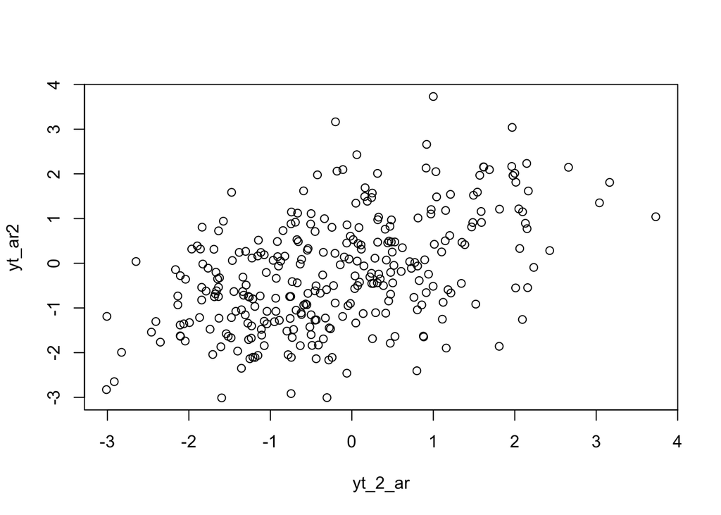

```r
plot(y=yt_ar2,x=yt_2_ar)
```

Berdasarkan scatterplot tersebut, terlihat bahwa terdapat hubungan positif antara $Y_t$ dengan $Y_{t-2}$. Hal ini sesuai dengan teori yang ada

```r
cor(yt_ar2,yt_2_ar)
```

```
## [1] 0.4860114
```

Korelasi antara $Y_t$ dengan $Y_{t-2}$ dari hasil simulasi mendekati perhitungan teoritis yaitu $\rho_2=\phi^2=0.449$.

#### Korelasi antara $Y_t$ dengan $Y_{t-3}$

```r
#Yt
yt_ar3 <- ar[-c(1,2,3)]
yt_ar3
```

```
##   [1]  2.01326343  1.04072348  1.81313140  1.48506573  1.21094326  0.91188419
##   [7]  1.54125407  2.13047623  1.59121896  0.89456334  0.91325557  0.07632206
##  [13] -0.65727101  0.44031922  0.48448683  0.45546788  0.47605865  0.49577432
##  [19] -0.69249780  0.25079827  0.91861252  1.57044350  2.65967017  1.96811889
##  [25]  2.14675844  3.03963866  2.23331596  1.35213032 -0.09292780  0.46838318
##  [31]  0.13919826  0.82699820 -1.12511171 -0.38734396 -0.73214024 -0.67040187
##  [37] -1.66066297 -0.43738525 -0.61753708 -1.26705722 -1.14640353 -1.70707726
##  [43]  0.51660196 -2.04083765 -0.04667257 -0.35752100 -0.94968195 -0.26206376
##  [49] -1.30768465 -1.46678748 -1.15463659  0.06158995  0.16308129  2.42903976
##  [55]  1.68927189  0.28370469  2.09379470  0.11279964 -1.25785703  0.40907891
##  [61] -0.75697389  0.76217362 -1.23429214 -0.76294311 -1.67511767 -0.74564408
##  [67] -0.68405519 -2.91571521 -1.04996249 -2.64898654 -0.20643239  0.03946256
##  [73]  0.22197143 -0.28296221 -0.30505651 -2.16447733 -3.00649589 -0.14238097
##  [79] -1.18830952 -0.03422377 -2.10703882  0.09413759 -1.38224350 -0.42200867
##  [85]  0.24310044  1.97815886  1.47042587  1.96269398  0.81235965  2.16633801
```

[output cut: 35 more lines]

```r
#Yt-2
yt_3_ar <- ar[-c(298,299,300)]
yt_3_ar
```

```
##   [1]  1.00000000  2.00000000  3.73070010  2.01326343  1.04072348  1.81313140
##   [7]  1.48506573  1.21094326  0.91188419  1.54125407  2.13047623  1.59121896
##  [13]  0.89456334  0.91325557  0.07632206 -0.65727101  0.44031922  0.48448683
##  [19]  0.45546788  0.47605865  0.49577432 -0.69249780  0.25079827  0.91861252
##  [25]  1.57044350  2.65967017  1.96811889  2.14675844  3.03963866  2.23331596
##  [31]  1.35213032 -0.09292780  0.46838318  0.13919826  0.82699820 -1.12511171
##  [37] -0.38734396 -0.73214024 -0.67040187 -1.66066297 -0.43738525 -0.61753708
##  [43] -1.26705722 -1.14640353 -1.70707726  0.51660196 -2.04083765 -0.04667257
##  [49] -0.35752100 -0.94968195 -0.26206376 -1.30768465 -1.46678748 -1.15463659
##  [55]  0.06158995  0.16308129  2.42903976  1.68927189  0.28370469  2.09379470
##  [61]  0.11279964 -1.25785703  0.40907891 -0.75697389  0.76217362 -1.23429214
##  [67] -0.76294311 -1.67511767 -0.74564408 -0.68405519 -2.91571521 -1.04996249
##  [73] -2.64898654 -0.20643239  0.03946256  0.22197143 -0.28296221 -0.30505651
##  [79] -2.16447733 -3.00649589 -0.14238097 -1.18830952 -0.03422377 -2.10703882
##  [85]  0.09413759 -1.38224350 -0.42200867  0.24310044  1.97815886  1.47042587
```

[output cut: 35 more lines]

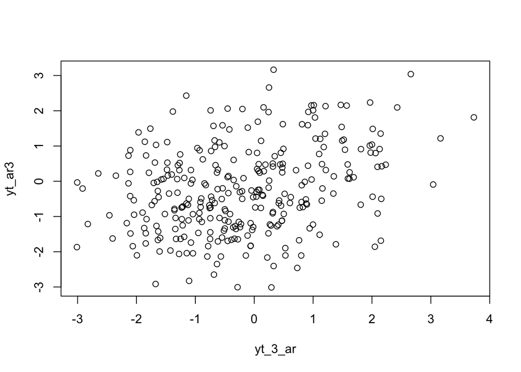

```r
plot(y=yt_ar3,x=yt_3_ar)
```

```r
cor(yt_ar3,yt_3_ar)
```

```
## [1] 0.3005679
```

Korelasi antara $Y_t$ dengan $Y_{t-3}$ dari hasil simulasi mendekati perhitungan teoritis yaitu $\rho_2=\phi^2=0.36$.

# PROSES ARMA(2,2)

```r
set.seed(98)
n = length(wn)
phi1 = 0.5
phi2 = 0.2
theta1 = 0.4
theta2 = 0.6

y.arma=c(1:n)
for (i in 3:n){y.arma[i] = phi1*y.arma[i-1] + theta1*wn[i-1]+wn[i] + phi2*y.arma[i-2] + theta2*wn[i-2]+wn[i]}
y.arma
```

```
##   [1]  1.00000000  2.00000000  6.05924197  4.37632992  3.39350225  3.91617979
##   [7]  3.30631884  3.33017592  2.60967741  3.72435076  5.08194456  4.69816542
##  [13]  3.50476427  2.98725689  0.93895174 -0.82428836  0.59626250  0.69946265
##  [19]  1.32983183  1.39519624  1.43253463 -0.91836985  0.50885879  1.51198023
##  [25]  3.65113760  6.49283548  5.93791238  6.67316680  8.11626026  6.96856661
##  [31]  5.41986395  1.69383779  1.70999802  0.40932574  1.99019684 -1.83629304
##  [37] -0.72882936 -2.29451050 -1.86623806 -4.02890183 -1.94137668 -2.40650217
##  [43] -3.04361846 -3.17019645 -4.63298400 -0.33749483 -4.89930047 -0.59973397
##  [49] -1.95822501 -2.07038453 -1.11851953 -3.29000902 -3.61389092 -3.68060189
##  [55] -1.21874946 -0.34198510  4.96026471  4.44800747  2.70054124  5.31463383
##  [61]  1.23333953 -1.21431772  0.38269453 -2.10503064  1.46700488 -2.61789928
##  [67] -1.56229899 -4.39598794 -2.61910115 -2.67143866 -6.55243898 -3.67664421
##  [73] -7.46738722 -2.10243691 -1.59303977  0.33586845 -0.45345832 -0.59011505
##  [79] -4.62075460 -7.06181662 -2.78604670 -4.23746896 -0.62919993 -4.94075286
##  [85] -0.67507461 -3.99105525 -1.34043219 -0.51194868  3.80035269  3.87797556
```

[output cut: 35 more lines]

```r
arma11 <- arima.sim(list(order=c(2,0,2), ar = c(0.5, 0.2), ma = c(0.4, 0.6)), n=300)
arma11
```

```
## Time Series:
## Start = 1
## End = 300
## Frequency = 1
##   [1] -2.749172211 -2.428874885 -3.717361657 -4.390738446 -5.630013455
##   [6] -3.737831151 -4.326979825 -2.794733490 -5.464430440 -3.871333334
##  [11] -3.557692908 -2.398807200 -2.095107829 -1.707707502 -4.089141162
##  [16] -4.512684377 -3.889357382 -2.360090328 -1.611453004 -1.593950710
##  [21] -1.074236075  0.149098166  0.107011980 -0.022215904 -1.010385078
##  [26] -0.183543904  0.584272561  2.177752618  3.356531084  1.273733031
##  [31]  1.503778283  1.646641578  1.245763922  0.203468527 -0.068119994
##  [36] -0.702489060 -1.476643776 -2.484834578 -1.109749667 -1.928606127
##  [41] -1.969527798 -2.214975664 -2.917343463 -1.654904287  0.599945571
##  [46]  1.139927106  2.971878360  0.973315681  1.637069624 -1.007914734
##  [51] -0.648556290 -0.082642176 -0.260937277  1.101849982  0.480387983
```

[output cut: 49 more lines]

Buat plot time series, plot ACF, plot PACF, dan plot EACF. Identifikasi apakah data tersebut stasioner

### Plot Time Series

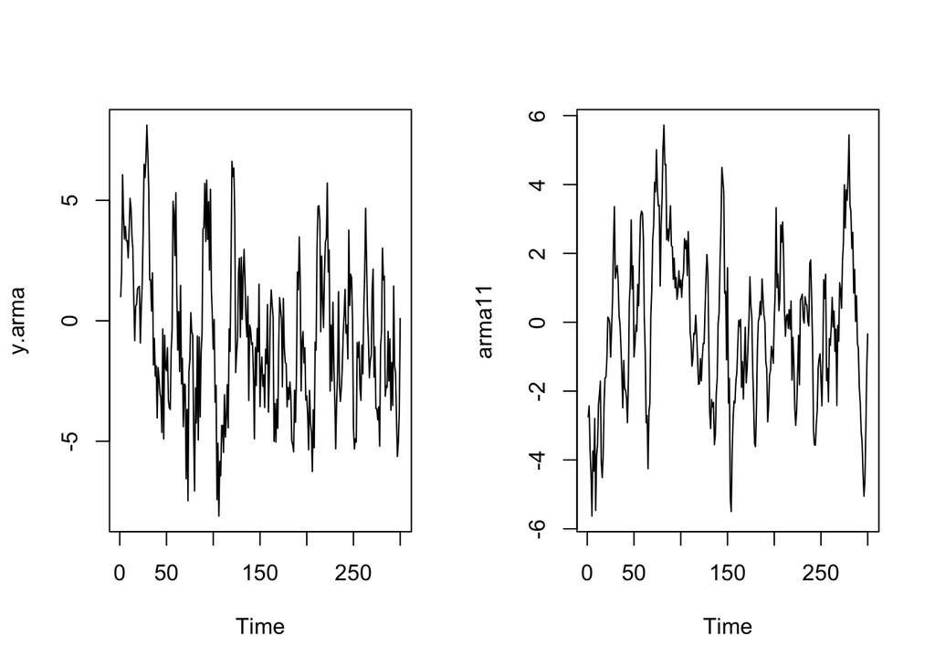

```r
par(mfrow = c(1, 2))
ts.plot(y.arma)
ts.plot(arma11)
```

```r
par(mfrow = c(1, 1))
```

Berdasarkan plot time series tersebut, terlihat bahwa model ARMA(2,2) cenderung stasioner dalam rataan

### Plot ACF

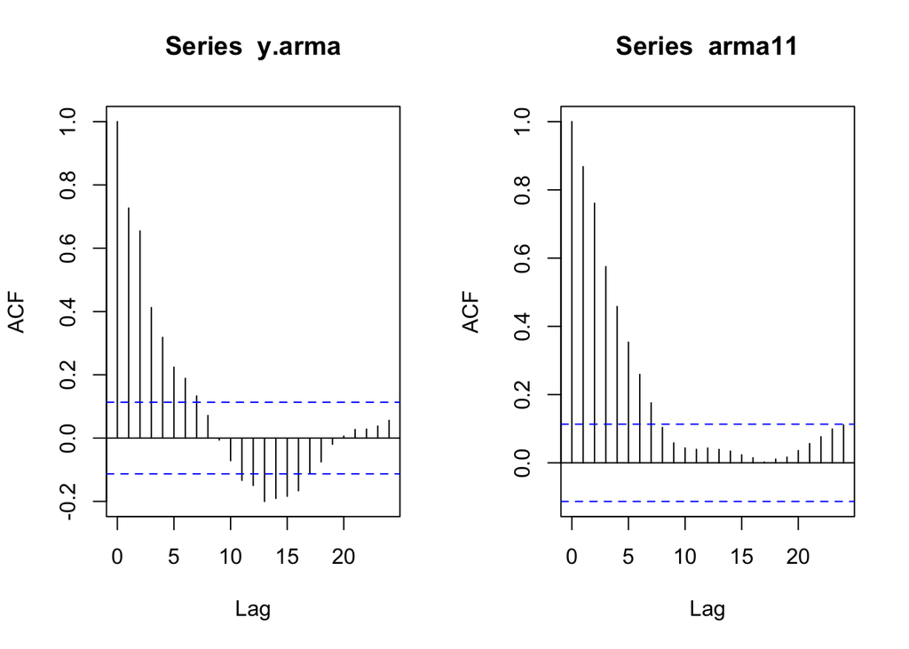

```r
par(mfrow = c(1, 2))
acf(y.arma)
acf(arma11)
```

```r
par(mfrow = c(1, 1))
```

Berdasarkan plot ACF tersebut, terlihat bahwa model ARMA(2,2) hasil simulasi memiliki plot ACF yang *tails off*, sesuai dengan teori yang ada

### Plot PACF

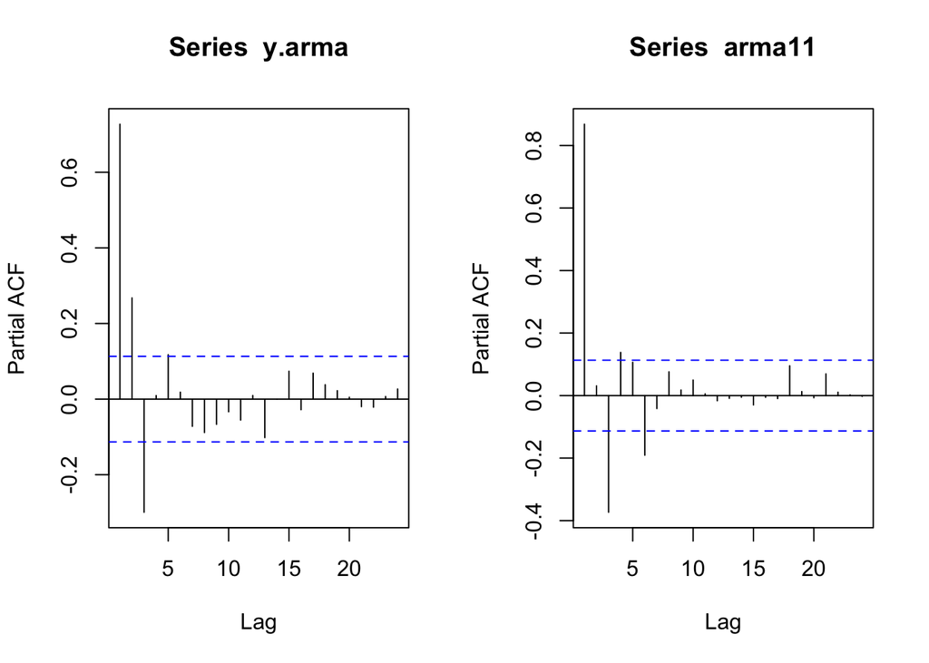

```r
par(mfrow = c(1, 2))
pacf(y.arma)
pacf(arma11)
```

```r
par(mfrow = c(1, 1))
```

Berdasarkan plot PACF tersebut, terlihat bahwa model ARMA(2,2) hasil simulasi memiliki plot PACF yang *tails off*, sesuai dengan teori

### Plot EACF

```r
TSA::eacf(y.arma)
```

```
## AR/MA
##   0 1 2 3 4 5 6 7 8 9 10 11 12 13
## 0 x x x x x x x o o o x  x  x  x
## 1 x x x o o o o o o o o  o  o  o
## 2 x x o o o o o o o o o  o  o  o
## 3 o x o x o o o o o o o  o  o  o
## 4 o x x o o o o o o o o  o  o  o
## 5 x x o o o o o o o o o  o  o  o
## 6 x x o o o o o o o o o  o  o  o
## 7 x x o o o o o o o o o  o  o  o
```

```r
TSA::eacf(arma11)
```

```
## AR/MA
##   0 1 2 3 4 5 6 7 8 9 10 11 12 13
## 0 x x x x x x x o o o o  o  o  o
## 1 o x x o o o o o o o o  o  o  o
## 2 o x o o o o o o o o o  o  o  o
## 3 x x o x x o o o o o o  o  o  o
## 4 x x x o o o o o o o o  o  o  o
## 5 x x x o x x o o o o o  o  o  o
## 6 x x o x o x o o o o o  o  o  o
## 7 x x o x o x o o o o o  o  o  o
```

### Scatterplot Antar Lag

#### Korelasi antara $Y_t$ dengan $Y_{t-1}$

```r
#Yt
yt_arma <- arma11[-1]
yt_arma
```

```
##   [1] -2.428874885 -3.717361657 -4.390738446 -5.630013455 -3.737831151
##   [6] -4.326979825 -2.794733490 -5.464430440 -3.871333334 -3.557692908
##  [11] -2.398807200 -2.095107829 -1.707707502 -4.089141162 -4.512684377
##  [16] -3.889357382 -2.360090328 -1.611453004 -1.593950710 -1.074236075
##  [21]  0.149098166  0.107011980 -0.022215904 -1.010385078 -0.183543904
##  [26]  0.584272561  2.177752618  3.356531084  1.273733031  1.503778283
##  [31]  1.646641578  1.245763922  0.203468527 -0.068119994 -0.702489060
##  [36] -1.476643776 -2.484834578 -1.109749667 -1.928606127 -1.969527798
##  [41] -2.214975664 -2.917343463 -1.654904287  0.599945571  1.139927106
##  [46]  2.971878360  0.973315681  1.637069624 -1.007914734 -0.648556290
##  [51] -0.082642176 -0.260937277  1.101849982  0.480387983  1.965224487
##  [56]  3.070178341  3.227425447  3.165273092  2.453740072  0.139617919
##  [61] -0.866849141 -2.919141390 -2.709978611 -4.254166034 -2.590097275
##  [66] -2.355863408  0.196429432  0.917120447  2.394631367  2.806586250
##  [71]  4.063783617  3.791500660  5.011812793  3.877539820  3.379273947
```

[output cut: 45 more lines]

```r
#Yt-1
yt_1_arma <- arma11[-300]
yt_1_arma
```

```
##   [1] -2.749172211 -2.428874885 -3.717361657 -4.390738446 -5.630013455
##   [6] -3.737831151 -4.326979825 -2.794733490 -5.464430440 -3.871333334
##  [11] -3.557692908 -2.398807200 -2.095107829 -1.707707502 -4.089141162
##  [16] -4.512684377 -3.889357382 -2.360090328 -1.611453004 -1.593950710
##  [21] -1.074236075  0.149098166  0.107011980 -0.022215904 -1.010385078
##  [26] -0.183543904  0.584272561  2.177752618  3.356531084  1.273733031
##  [31]  1.503778283  1.646641578  1.245763922  0.203468527 -0.068119994
##  [36] -0.702489060 -1.476643776 -2.484834578 -1.109749667 -1.928606127
##  [41] -1.969527798 -2.214975664 -2.917343463 -1.654904287  0.599945571
##  [46]  1.139927106  2.971878360  0.973315681  1.637069624 -1.007914734
##  [51] -0.648556290 -0.082642176 -0.260937277  1.101849982  0.480387983
##  [56]  1.965224487  3.070178341  3.227425447  3.165273092  2.453740072
##  [61]  0.139617919 -0.866849141 -2.919141390 -2.709978611 -4.254166034
##  [66] -2.590097275 -2.355863408  0.196429432  0.917120447  2.394631367
##  [71]  2.806586250  4.063783617  3.791500660  5.011812793  3.877539820
```

[output cut: 45 more lines]

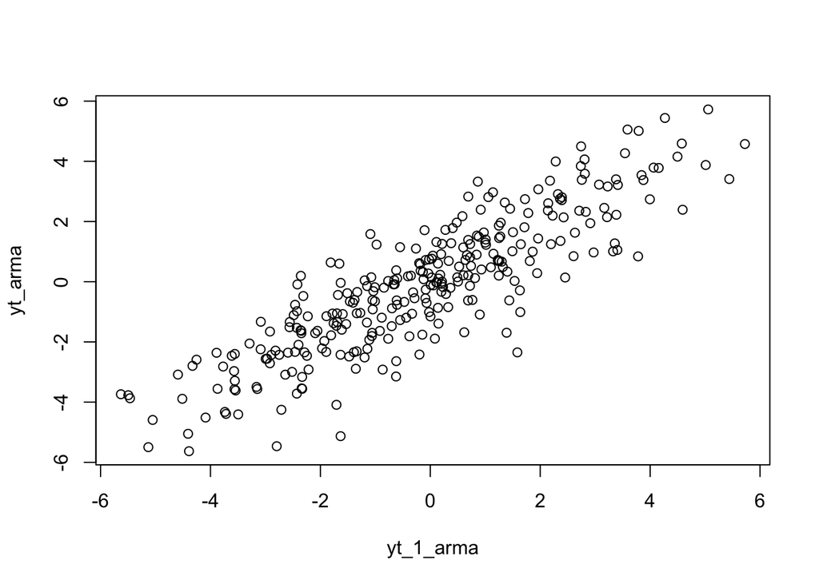

```r
plot(y=yt_arma,x=yt_1_arma)
```

Berdasarkan scatterplot tersebut, terlihat bahwa terdapat hubungan positif antara $Y_t$ dengan $Y_{t-1}$. Hal ini sesuai dengan teori yang ada

```r
cor(yt_arma,yt_1_arma)
```

```
## [1] 0.8699122
```

#### Korelasi antara $Y_t$ dengan $Y_{t-2}$

```r
#Yt
yt_arma <- arma11[-c(1,2)]
yt_arma
```

```
##   [1] -3.717361657 -4.390738446 -5.630013455 -3.737831151 -4.326979825
##   [6] -2.794733490 -5.464430440 -3.871333334 -3.557692908 -2.398807200
##  [11] -2.095107829 -1.707707502 -4.089141162 -4.512684377 -3.889357382
##  [16] -2.360090328 -1.611453004 -1.593950710 -1.074236075  0.149098166
##  [21]  0.107011980 -0.022215904 -1.010385078 -0.183543904  0.584272561
##  [26]  2.177752618  3.356531084  1.273733031  1.503778283  1.646641578
##  [31]  1.245763922  0.203468527 -0.068119994 -0.702489060 -1.476643776
##  [36] -2.484834578 -1.109749667 -1.928606127 -1.969527798 -2.214975664
##  [41] -2.917343463 -1.654904287  0.599945571  1.139927106  2.971878360
##  [46]  0.973315681  1.637069624 -1.007914734 -0.648556290 -0.082642176
##  [51] -0.260937277  1.101849982  0.480387983  1.965224487  3.070178341
##  [56]  3.227425447  3.165273092  2.453740072  0.139617919 -0.866849141
##  [61] -2.919141390 -2.709978611 -4.254166034 -2.590097275 -2.355863408
##  [66]  0.196429432  0.917120447  2.394631367  2.806586250  4.063783617
##  [71]  3.791500660  5.011812793  3.877539820  3.379273947  3.403326254
```

[output cut: 45 more lines]

```r
#Yt-1
yt_2_arma <- arma11[-c(299,300)]
yt_2_arma
```

```
##   [1] -2.749172211 -2.428874885 -3.717361657 -4.390738446 -5.630013455
##   [6] -3.737831151 -4.326979825 -2.794733490 -5.464430440 -3.871333334
##  [11] -3.557692908 -2.398807200 -2.095107829 -1.707707502 -4.089141162
##  [16] -4.512684377 -3.889357382 -2.360090328 -1.611453004 -1.593950710
##  [21] -1.074236075  0.149098166  0.107011980 -0.022215904 -1.010385078
##  [26] -0.183543904  0.584272561  2.177752618  3.356531084  1.273733031
##  [31]  1.503778283  1.646641578  1.245763922  0.203468527 -0.068119994
##  [36] -0.702489060 -1.476643776 -2.484834578 -1.109749667 -1.928606127
##  [41] -1.969527798 -2.214975664 -2.917343463 -1.654904287  0.599945571
##  [46]  1.139927106  2.971878360  0.973315681  1.637069624 -1.007914734
##  [51] -0.648556290 -0.082642176 -0.260937277  1.101849982  0.480387983
##  [56]  1.965224487  3.070178341  3.227425447  3.165273092  2.453740072
##  [61]  0.139617919 -0.866849141 -2.919141390 -2.709978611 -4.254166034
##  [66] -2.590097275 -2.355863408  0.196429432  0.917120447  2.394631367
##  [71]  2.806586250  4.063783617  3.791500660  5.011812793  3.877539820
```

[output cut: 45 more lines]

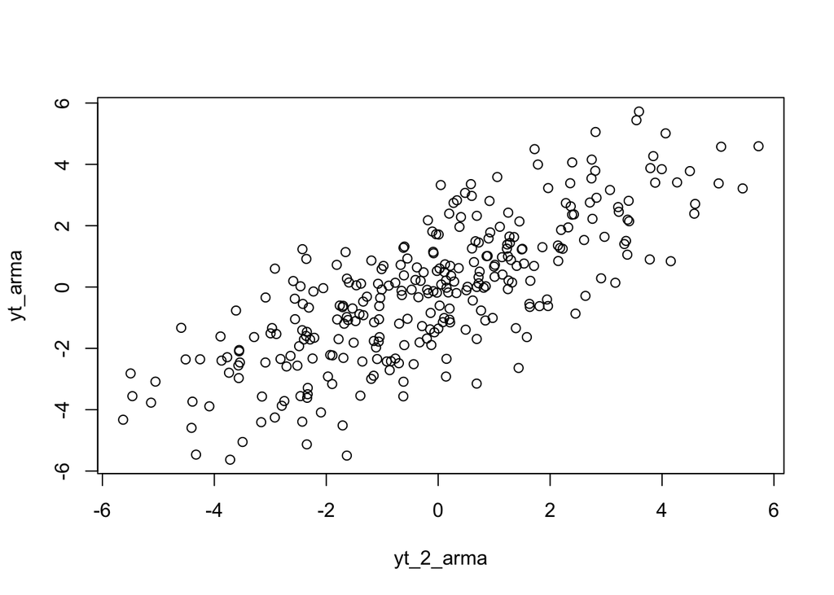

```r
plot(y=yt_arma,x=yt_2_arma)
```

```r
cor(yt_arma,yt_2_arma)
```

```
## [1] 0.7643909
```

#### Korelasi antara $Y_t$ dengan $Y_{t-3}$

```r
#Yt
yt_arma <- arma11[-c(1,2,3)]
yt_arma
```

```
##   [1] -4.390738446 -5.630013455 -3.737831151 -4.326979825 -2.794733490
##   [6] -5.464430440 -3.871333334 -3.557692908 -2.398807200 -2.095107829
##  [11] -1.707707502 -4.089141162 -4.512684377 -3.889357382 -2.360090328
##  [16] -1.611453004 -1.593950710 -1.074236075  0.149098166  0.107011980
##  [21] -0.022215904 -1.010385078 -0.183543904  0.584272561  2.177752618
##  [26]  3.356531084  1.273733031  1.503778283  1.646641578  1.245763922
##  [31]  0.203468527 -0.068119994 -0.702489060 -1.476643776 -2.484834578
##  [36] -1.109749667 -1.928606127 -1.969527798 -2.214975664 -2.917343463
##  [41] -1.654904287  0.599945571  1.139927106  2.971878360  0.973315681
##  [46]  1.637069624 -1.007914734 -0.648556290 -0.082642176 -0.260937277
##  [51]  1.101849982  0.480387983  1.965224487  3.070178341  3.227425447
##  [56]  3.165273092  2.453740072  0.139617919 -0.866849141 -2.919141390
##  [61] -2.709978611 -4.254166034 -2.590097275 -2.355863408  0.196429432
##  [66]  0.917120447  2.394631367  2.806586250  4.063783617  3.791500660
##  [71]  5.011812793  3.877539820  3.379273947  3.403326254  1.055633958
```

[output cut: 45 more lines]

```r
#Yt-1
yt_3_arma <- arma11[-c(298,299,300)]
yt_3_arma
```

```
##   [1] -2.749172211 -2.428874885 -3.717361657 -4.390738446 -5.630013455
##   [6] -3.737831151 -4.326979825 -2.794733490 -5.464430440 -3.871333334
##  [11] -3.557692908 -2.398807200 -2.095107829 -1.707707502 -4.089141162
##  [16] -4.512684377 -3.889357382 -2.360090328 -1.611453004 -1.593950710
##  [21] -1.074236075  0.149098166  0.107011980 -0.022215904 -1.010385078
##  [26] -0.183543904  0.584272561  2.177752618  3.356531084  1.273733031
##  [31]  1.503778283  1.646641578  1.245763922  0.203468527 -0.068119994
##  [36] -0.702489060 -1.476643776 -2.484834578 -1.109749667 -1.928606127
##  [41] -1.969527798 -2.214975664 -2.917343463 -1.654904287  0.599945571
##  [46]  1.139927106  2.971878360  0.973315681  1.637069624 -1.007914734
##  [51] -0.648556290 -0.082642176 -0.260937277  1.101849982  0.480387983
##  [56]  1.965224487  3.070178341  3.227425447  3.165273092  2.453740072
##  [61]  0.139617919 -0.866849141 -2.919141390 -2.709978611 -4.254166034
##  [66] -2.590097275 -2.355863408  0.196429432  0.917120447  2.394631367
##  [71]  2.806586250  4.063783617  3.791500660  5.011812793  3.877539820
```

[output cut: 45 more lines]

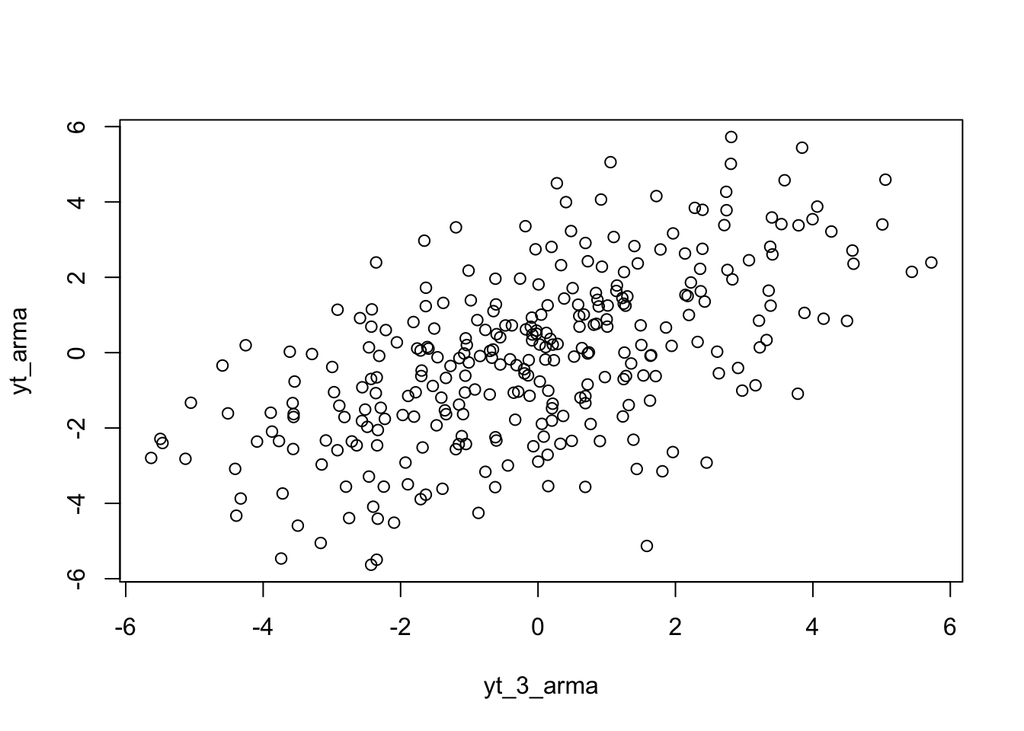

```r
plot(y=yt_arma,x=yt_3_arma)
```

```r
cor(yt_arma,yt_3_arma)
```

```
## [1] 0.5816606
```